# 통계밥법론 Chap3 실습코드

202140191 엄태훈

2021-05-15(SAT)

# Chap3 Statistics Concepts

*평균(Mean)*은 모든 관측값을 더해서 관측값 개수로 나눈 것이다. 특히, 조사자들이 모평균을 추정하고자 할 때 가장 흔하게 사용된다.  
즉, 평균은 관심특성의 변수라고 할 수 있다.  
표본평균은 다음과 같은 식을 사용하여 구할 수 있다.

$$\overline{x} = \frac {\sum_{i=1}^n x_i}{n}$$

*분산(Variance)*은 편차를 제곱한 후 모두 더해서 전체 자료의 개수로 나눠준 값을 말한다. 즉, 편차의 제곱합의 평균이라고 말할 수 있다.

하지만, 편차의 제곱을 평균한 값이므로 자료의 단위가 제곱으로 바뀌어 기존의 자료와 단위가 달라지는 문제가 있다.  
표본분산은 다음과 같은 식을 사용하여 구할 수 있다.

$$s_x^2 = \frac {\sum_{i=1}^n (x_i - \mu)^2}{n-1}$$

*표준편차(Standard error)*는 자료의 산포도를 나타내는 수치로 분산에 제곱근을 취한 값이다. 측정값이 평균으로부터 멀리 떨어져 있을수록 표준편차는 커지게 된다.  
분산으로 인해 달라진 단위를 해결하기 위해 등장한 개념이 바로 표준편차이다.

표준편차는 분산에 제곱근을 취하기 때문에 제곱으로 인해 변했던 단위를 원래대로 바꿔준다.  
표본 표준편차는 다음과 같은 식을 사용하여 구할 수 있다.

$$s_x = \sqrt\frac {\sum_{i=1}^n (x_i - \mu)^2}{n-1}$$

*상관계수(Correlation)*란 두 변수 x,y 사이에 상관관계 정도를 나타내는 수치이다.  
x가 증가할 때, y가 증가하면 양의 상관관계이고 x가 감소할 때 y가 감소하면 음의 상관관계이다.

$$r = \frac{S_{xy}}{\sqrt {S_{xx}}\sqrt{S_{yy}}}$$

R에서는 `cor`함수를 통해 상관계수를 구할 수 있다.  
`corrplot`을 통해 상관계수의 그림을 그릴수도 있다.

```r
data(iris)
cor(iris[,c(1:4)])
```

```
##              Sepal.Length Sepal.Width Petal.Length Petal.Width
## Sepal.Length    1.0000000  -0.1175698    0.8717538   0.8179411
## Sepal.Width    -0.1175698   1.0000000   -0.4284401  -0.3661259
## Petal.Length    0.8717538  -0.4284401    1.0000000   0.9628654
## Petal.Width     0.8179411  -0.3661259    0.9628654   1.0000000
```

Seapl.Length와 Petal.Length, Petal.Width는 양의 상관관계를 가지며, Sepal.Length와 Sepal.Width는 음의 상관관계를 가지는 것을 확인할 수 있다.

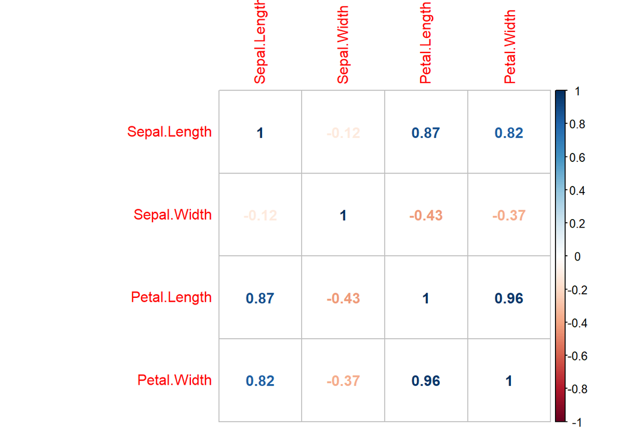

```r
library(corrplot)
corrplot(cor(iris[,c(1:4)]),method = "number")
```

## 3.4.1 Histogram

*히스토그램*은 도수분포표를 시각적으로 표현한 막대그래프이다.  
가로축에는 계급을, 세로축에 도수를 취한다.  
각 막대의 높이는 해당 계급에 포함되는 자료의 개수를 의미한다.

R에서는 `hist(연속형 데이터)`를 통해 히스토그램을 그릴 수 있다.  
- *xlab*: x축의 이름을 설정한다.  
- *ylab*: y축의 이름을 설정한다.  
- *main*: 그래프의 title을 설정한다.

```r
library(HH)
```

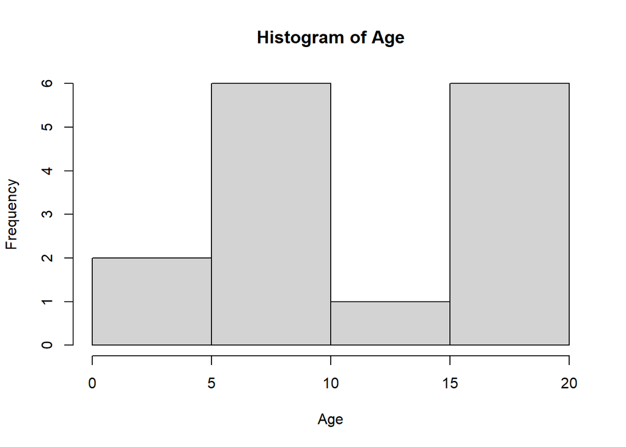

```r
b = c(1:20)
freq = sample(b,15,replace = TRUE)
hist(freq,xlab="Age",ylab="Frequency",main="Histogram of Age")
```

## 3.3.4.3 Boxplots

`quantile`함수를 이용하면 데이터의 분위수를 확인할 수 있다.

```r
data(tv)
quantile(tv$male.life.exp)
```

```
##    0%   25%   50%   75%  100%
## 50.00 59.75 66.00 69.50 76.00
```

`quantile`함수를 이용하고 `probs`옵션을 이용하면 원하는 위치의 사분위수를 확인할 수 있다.

```r
# 90% 사분위수를 찾는다.
quantile(tv$male.life.exp,probs=0.9)
```

```
##  90%
## 73.1
```

*Boxplot*은 특정한 수치 값을 기반으로 그려진, 자료 특성이 요약된 그래프이다.  
Q1, 중앙값, Q3, 최댓값, 최솟값의 정보를 한 그림 안에 보여준다.  
박스안의 가운데 실선은 중앙값을 나타내며, 박스 위의 선과 아래 선은 각각 Q3, Q1을 나타낸다.  
위쪽 아래쪽 수염은 각각 최댓값 최솟값을 나타낸다.

`Boxplot(연속형 데이터)`를 이용하여 그릴 수 있다.

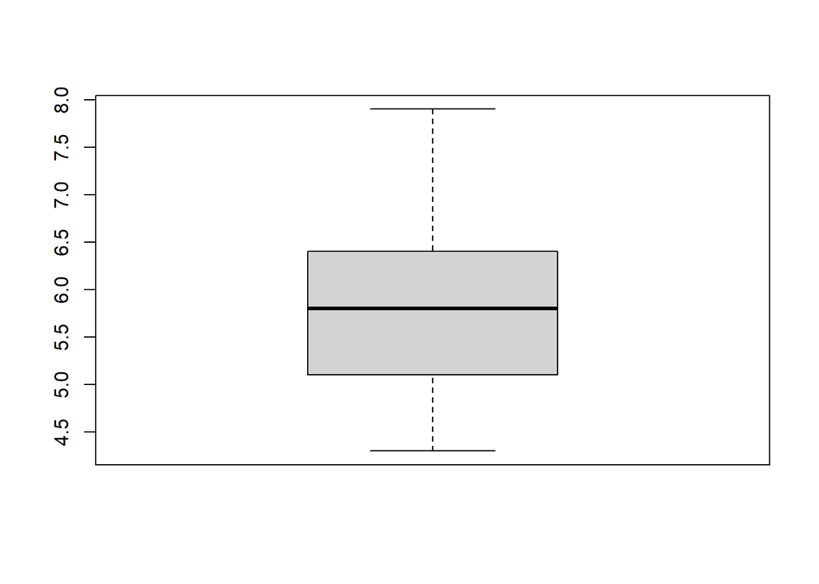

```r
boxplot(iris$Sepal.Length)
```

`horizontal = T`옵션을 이용하면 Boxplot을 회전시켜 나타낼 수 있다.

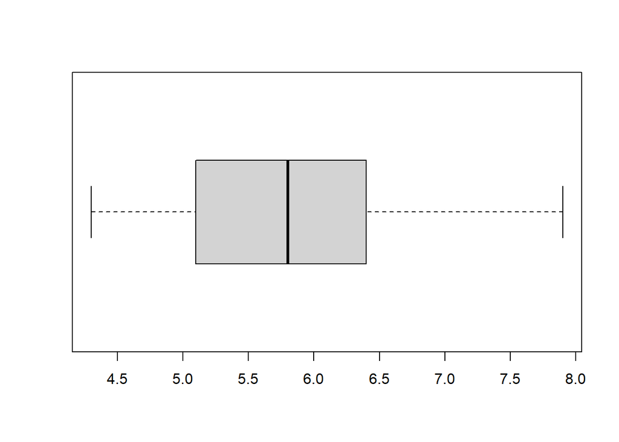

```r
boxplot(iris$Sepal.Length,horizontal = T)
```

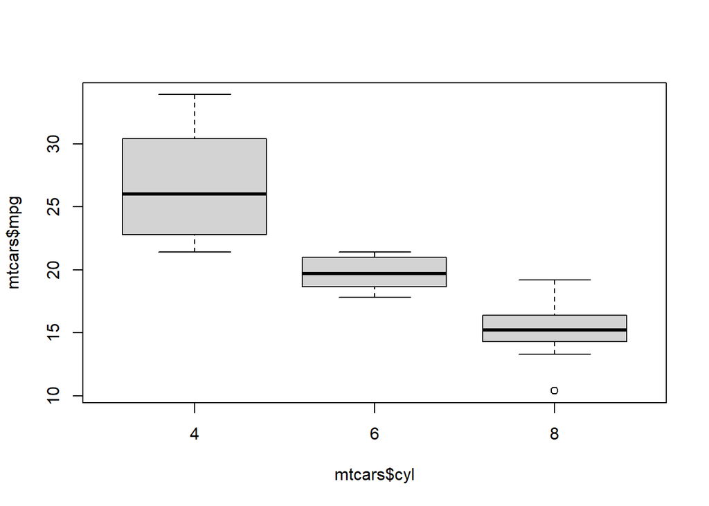

```r
data(mtcars)
boxplot(mtcars$mpg~mtcars$cyl)
```

Formula의 형태로 지정해준 결과, cyl의 갯수에 따라서 mpg에 대한 boxplot을 그리는 것을 확인할 수 있다.

col옵션을 이용하여 box의 색깔 또한 지정해줄 수 있다.

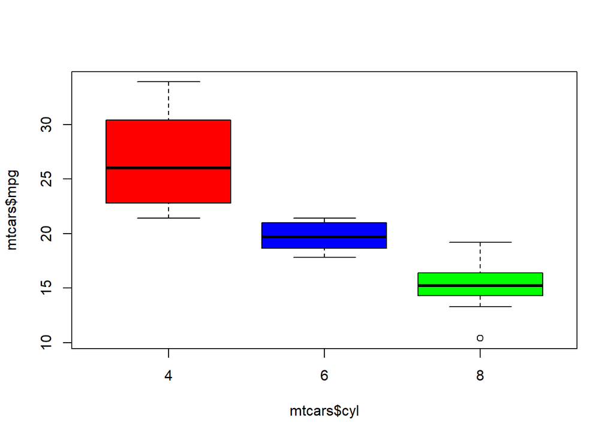

```r
data(mtcars)
boxplot(mtcars$mpg~mtcars$cyl,col=c("red","blue","green"))
```

## 3.4.1 The Binomial Distribution

*베르누이* 시행은 결과가 두 가지 중 하나로만 나오는 실험이나 시행을 일컫는다.  
성공확률이 p인 베르누이 시행을 n번 반복하는 경우, 성공한 횟수를 확률 변수 X라고 해보자.  
이 확률변수 X의 확률변수를 모수가 (n,p)인 *이항분포*라고 한다.

$$X \sim B(n,p)$$

`pbinom(size,prob,q)` 함수를 이용하면 이항분포의 누적확률 값을 계산할 수 있다.  
- *size*: n의 크기를 나타낸다.  
- *prob*: 성공 확률을 나타낸다.  
- *q*: 구하고 싶은 누적 성공 횟수

`dbinom(size,prob,x)` 함수는 이항분포의 확률값을 계산한다.  
- *size*: n의 크기를 나타낸다.  
- *prob*: 성공 확률을 나타낸다.  
- *x*: 성공 횟수를 나타낸다.

```r
pbinom(size=15,prob=.4,q=6)
```

```
## [1] 0.6098132
```

```r
dbinom(size=15,prob=.4,x=6)
```

```
## [1] 0.2065976
```

### NTplot

`NTplot`함수는 정규분포 및 t분포에 대한 검정과 신뢰 구간을 나타내는 그림을 그린다.  
`shiny = TRUE`옵션을 지정하면 모델의 파라미터를 변경에 따른 검정과 신뢰구간의 변화를 살펴볼 수 있다.

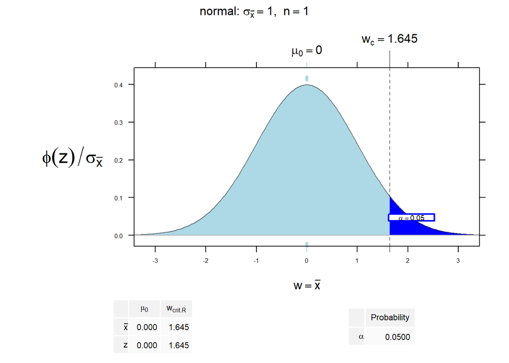

```r
NTplot(shiny=FALSE)
```

- *mean0*: 모평균의 값을 지정한다.
- *xbar*: 표본평균의 값을 지정한다.
- *sd*: 모표준편차를 설정한다. (표본의 크기를 설정하면 자동으로 표준오차를 구해준다.)
- *n*: 표본의 크기를 설정한다.

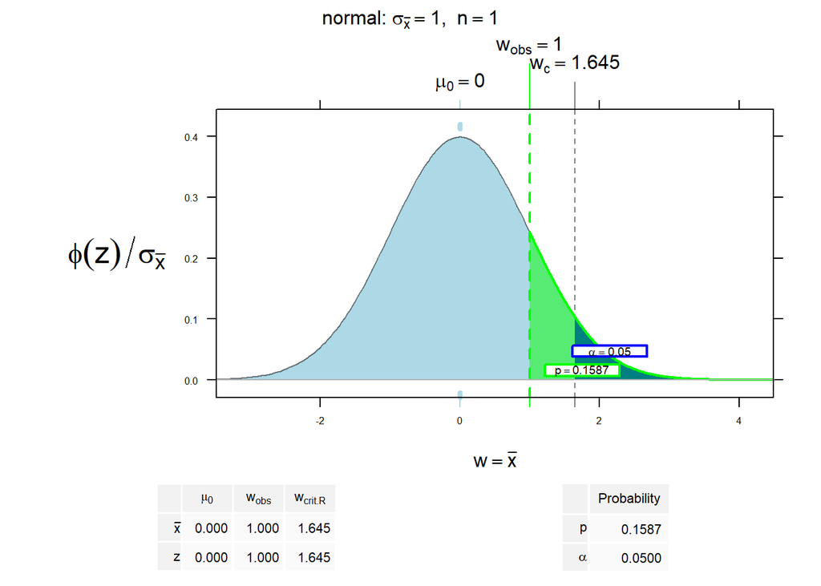

```r
NTplot(mean0=0,xbar=1,sd=1)
```

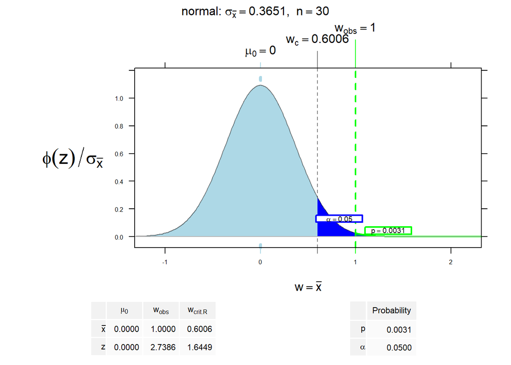

```r
NTplot(mean0=0,xbar=1,sd=2,n=30)
```

## 3.11.1 Simple Random Sampling

단순 무작위 추출법은 유한모집단에서 n개의 추출단위로 구성된 모든 부분집합들이 표본으로 선택될 확률이 같도록 설계된 표본추출방법이다.  
R에서는 `sample` 함수를 통해 쉽게 단순 무작위 추출법을 진행할 수 있다.

`sample(데이터, 원하는 표본 수, replace)` `replace=FALSE`를 지정하면 비복원 추출을 진행한다.

```r
a <- c(1:20)
sample(a,10,replace=FALSE)
```

```
##  [1]  8 17  2  9 12  4 10 15 13  5
```

```r
sample(a,10,replace=TRUE)
```

```
##  [1] 12  8 19 15  8 20 14 15  2  9
```

## 3.11.2 Stratified Random Sampling

모집단을 비슷한 성질을 갖는 2개 이상의 동질적인 층을 구분하고, 각 층으로부터 단순무작위추출방법을 적용하여 표본을 추출하는 방법이다.  
단순 무작위 추출법과 달리 층화추출을 위해서는 sampling 패키지를 설치해야 한다.  
`sampling` 패키지의 `strata` 함수를 통해 층화추출법을 할 수 있다.

`strata(data,startnames,size,method)`의 형태이다.  
- *data*: 표본 추출을 원하는 데이터  
- *startnames*: 표본 추출을 위해 나누고자 하는 층  
- *size*: 각 층에서 뽑을 표본의 수  
- *method*: 층화 추출에 이욜할 방법

*srswor*은 비복원 단순임의추출, *srswr*은 복원 단순임의 추출, *Poisson*은 포아송 추출, *Systematic*은 계통 추출방법을 의미한다.

`getdata(데이터,strata를 저장한 객체)`를 이용하여 데이터 프레임으로부터 그 표본의 데이터를 가져온다.

```r
library(sampling)
Sex <- c("M","F","M","M","M","F","F","M","F","M","M","F","F")
Height <- c(177,160,180,182,183,170,165,172,186,181,167,159,155)
Age <- c(20,22,23,21,22,24,20,28,24,23,21,24,26)
dat <- as.data.frame(cbind(Age,Height,Sex))
strat_sample<-strata(data=dat,stratanames = "Sex",size=c(3,3),method="srswor")

strat_data <- getdata(dat,strat_sample)
strat_data
```

```
##    Age Height Sex ID_unit      Prob Stratum
## 4   21    182   M       4 0.4285714       1
## 8   28    172   M       8 0.4285714       1
## 10  23    181   M      10 0.4285714       1
## 6   24    170   F       6 0.5000000       2
## 9   24    186   F       9 0.5000000       2
## 13  26    155   F      13 0.5000000       2
```

지정해준 옵션에 따라 층화추출이 적절하게 적용된 것을 확인할 수 있다.

*Prob*는 각 층에서 뽑힐 확률을 의미하고 *Stratum*은 층번호를 의미한다. (여기서 “M”은 1, “F”은 2)

## 3.11.3 Cluster Random Sampling

모집단을 조사단위 또는 집계단위를 모은 군집으로 나누고, 이들 군집들 중 일부의 군집을 추출한 후 추출된 군집에서 일부 또는 전부를 표본으로 추출하는 방법이다.  
R에서는 집락랜덤추출법에 대한 패키지를 제공하지 않아 간단한 예제를 통해 방법을 코드로 구현해 보았다.

```r
# AirPassengers 데이터는 1949~1960년대 까지의 월 별 비행기 탑승객 데이터이다.
data(AirPassengers)


AirPassengers <- data.frame(matrix(as.numeric(AirPassengers), ncol = 12, byrow = TRUE))
colnames(AirPassengers) <- c("Jan", "Feb", "Mar", "Apr", "May", "Jun", "Jul", "Aug", "Sep", "Oct", "Nov", "Dec")
rownames(AirPassengers) <- 1949:1960

# 시계열 데이터를 데이터 프레임 형태로 바꾸어 주었다.

df_1950s <- AirPassengers[c(1:4),]
df_1955s <- AirPassengers[c(5:8),]
df_1960s <- AirPassengers[c(9:12),]
```

집락추출법은 집단 내에서 이질적이고 집단 간 차이는 동질적이다.  
1950년대 초반, 1950년대 중반, 1950년대 후반으로 데이터를 나누어 집단내에 1~3월:봄, 4~6월:여름, 7~9월:가을, 10~12:월:겨울로 들어가게 하였다.

따라서, 집단 내에서는 계절 별로 데이터가 있으므로 이질적이고 다른 집단과는 동질적이다.

```r
# 나눠진 군집별로 각 2개의 데이터를 추출하였다.
cluster<-sample(df_1950s,2,replace=FALSE)
cluster1<-sample(df_1955s,2,replace=FALSE)
cluster2<-sample(df_1960s,2,replace=FALSE)
```

## 3.11.4 Systematic Random Sampling

첫 번째 요소는 무작위로 선정하고 목록의 매번 k번째 요소를 표본으로 선정하는 표본추출 방법이다.  
계통추출은 `doBy` 패키지의 `sampleBy` 함수를 이용한다.

```r
library(doBy)
sampleBy(formula=~Species,frac=0.2,data=iris,systematic = TRUE)
```

```
##               Sepal.Length Sepal.Width Petal.Length Petal.Width    Species
## setosa.1               5.1         3.5          1.4         0.2     setosa
## setosa.6               5.4         3.9          1.7         0.4     setosa
## setosa.11              5.4         3.7          1.5         0.2     setosa
## setosa.16              5.7         4.4          1.5         0.4     setosa
## setosa.21              5.4         3.4          1.7         0.2     setosa
## setosa.26              5.0         3.0          1.6         0.2     setosa
## setosa.31              4.8         3.1          1.6         0.2     setosa
## setosa.36              5.0         3.2          1.2         0.2     setosa
## setosa.41              5.0         3.5          1.3         0.3     setosa
## setosa.46              4.8         3.0          1.4         0.3     setosa
## versicolor.51          7.0         3.2          4.7         1.4 versicolor
## versicolor.56          5.7         2.8          4.5         1.3 versicolor
## versicolor.61          5.0         2.0          3.5         1.0 versicolor
## versicolor.66          6.7         3.1          4.4         1.4 versicolor
## versicolor.71          5.9         3.2          4.8         1.8 versicolor
## versicolor.76          6.6         3.0          4.4         1.4 versicolor
## versicolor.81          5.5         2.4          3.8         1.1 versicolor
## versicolor.86          6.0         3.4          4.5         1.6 versicolor
## versicolor.91          5.5         2.6          4.4         1.2 versicolor
## versicolor.96          5.7         3.0          4.2         1.2 versicolor
## virginica.101          6.3         3.3          6.0         2.5  virginica
## virginica.106          7.6         3.0          6.6         2.1  virginica
## virginica.111          6.5         3.2          5.1         2.0  virginica
## virginica.116          6.4         3.2          5.3         2.3  virginica
## virginica.121          6.9         3.2          5.7         2.3  virginica
## virginica.126          7.2         3.2          6.0         1.8  virginica
## virginica.131          7.4         2.8          6.1         1.9  virginica
## virginica.136          7.7         3.0          6.1         2.3  virginica
## virginica.141          6.7         3.1          5.6         2.4  virginica
## virginica.146          6.7         3.0          5.2         2.3  virginica
```

```r
# formula를 통해 그룹 데이터를 지정한다.
# frac을 통해 표본 추출의 비율을 정하고 systematic = TRUE를 통해 계통추출 여부를 결정한다.
```

## density plot

밀도함수의 그래프는 갖고 있는 데이터(x,y)를 이용해 plot을 그리면 쉽게 나타낼 수 있다.

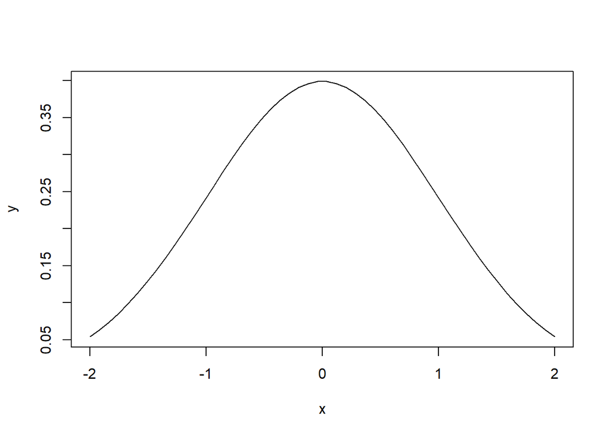

```r
x <- seq(-2,2,length=50)
y <- dnorm(x)
plot(x,y,type="l")
```

원하는 확률 구간을 색칠하고 싶은 경우 *xlim*,*ylim*에 대한 전처리를 진행한다.  
그 이후에, `polygon` 함수를 이용하여 다각형으로 채워 넣으면 된다.  
*polygon*함수의 *density*옵션은 색칠을 얼마나 진하게 할지의 정도를 나타낸다.

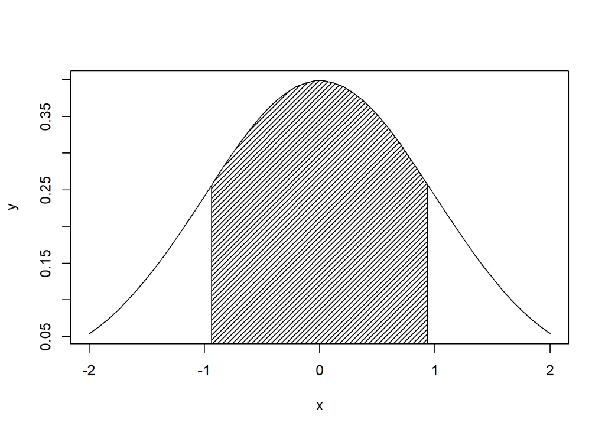

```r
xlim <- x[x >= -1 & x <= 1]
ylim <- y[x >= -1 & x <= 1]


xlim <- c(xlim[1],xlim,tail(xlim,1))
ylim <- c(0,ylim,0)

plot(x,y,type="l")
polygon(xlim,ylim,density=25)
```

이산형 확률변수의 density plot은 다음과 같이 그릴 수 있다.

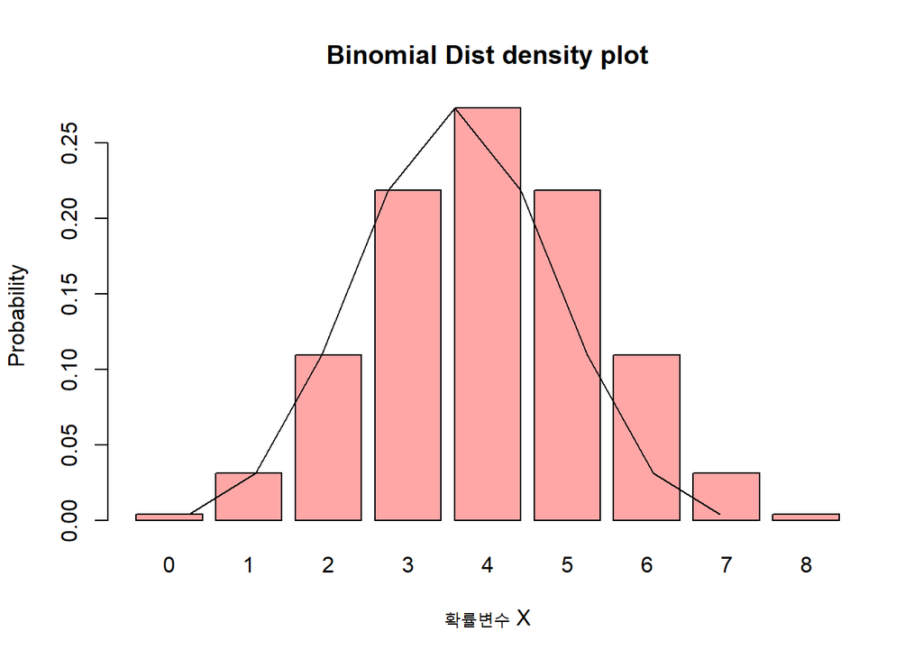

```r
binom <- dbinom(0:8,size=8,prob=0.5)
names(binom) <- c(0:8)
barplot(binom,ylab="Probability",xlab="확률변수 X",main="Binomial Dist density plot",col="#FFA7A7")
lines(binom)
```

이항분포에서 n의 크기가 커짐에 따라 어떻게 모양이 변하는지 살펴보자.

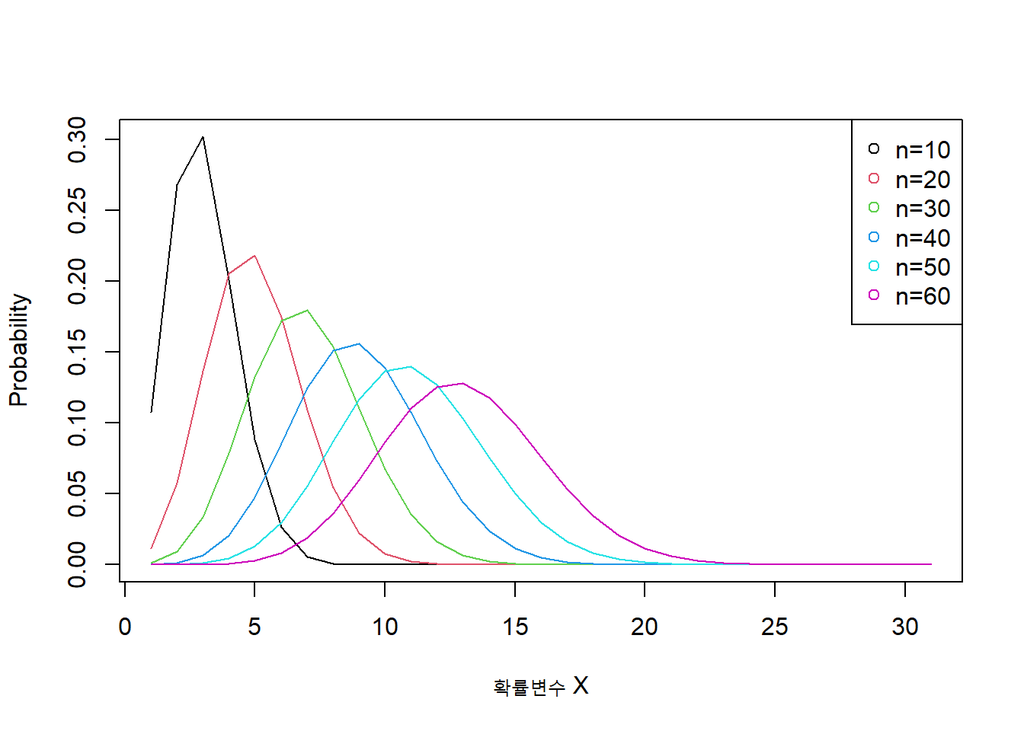

```r
b1 <- dbinom(0:30,10,0.2)
b2 <- dbinom(0:30,20,0.2)
b3 <- dbinom(0:30,30,0.2)
b4 <- dbinom(0:30,40,0.2)
b5 <- dbinom(0:30,50,0.2)
b6 <- dbinom(0:30,60,0.2)


plot(b1,type="l",xlab='확률변수 X',ylab="Probability",col=1)
lines(b2,type="l",col=2)
lines(b3,type="l",col=3)
lines(b4,type="l",col=4)
lines(b5,type="l",col=5)
lines(b6,type="l",col=6)
legend("topright",c('n=10','n=20','n=30','n=40','n=50','n=60'),col=1:6,pch=1)
```

이항분포의 경우, 반복횟수가 커질수록 정규분포와 같은 종모형에 가까워지는 것을 확인할 수 있다.

# Summary of Chapter3

- 우리가 분석을 진행하는 경우, 분석하고자 하는 모든 데이터를 이용할 수는 없다. 따라서 전체 데이터 중, 대표성을 가지는 일부 데이터만 추출하여 분석을 진행하는 경우가 많다. 이렇게 전체 모집단으로 부터 추출한 임의의 데이터를 **샘플**이라고 한다.
- **샘플**의 경우 모집단의 데이터를 대표할 수 있는 데이터로 구성이 되어있어야 한다. 따라서, 이러한 샘플을 추출하는 과정이 매우 중요한데, 이러한 과정을 **샘플링**이라고 한다. 대부분 샘플링은 모집단으로 부터 임의로 랜덤하게 추출하는 **단순무작위추출**방법이 가장 많이 쓰인다. 그 외에 **집락추출법**,**계층추출법**,**층화추출법**이 있다.
- 데이터로 부터 **샘플**을 얻게 되면 샘플을 통해서 데이터의 특성을 알아보고 모수에 대한 추정이 필요하다. 이때, 많이 쓰이는 통계적 개념들이 바로 **평균, 분산, 표준편차**이다. **평균**은 관심변수의 특성으로 모든 관측값을 관측값의 갯수로 나눈것이며, **분산, 표준편차**는 데이터가 얼마만큼 퍼져있는지에 대한 산포를 나타낸다. **표준편차**는 산포의 단위를 동일하게 만들기 위해 제곱근을 해주는 것이 **분산**과 다른 점이다.
- **히스토그램(Histogram)**은 도수의 분포를 그래프로 나타낸 것이다. 보통 가로는 계급, 세로는 도수를 뜻한다. 히스토그램은 도수가 어느 계급값에 집중되어 있는지 확인하는데에 쓰이기도 하지만, 데이터의 정규성을 확인하고자 할 때 쓰이기도한다. 데이터가 정규성을 따르게 되면 종모양을 띄게 되는데, 히스토그램을 통해 이러한 정보를 확인해 볼 수 있다. **
- **박스그림(Boxplot)**은 연속형 자료로부터 최소값,Q1,Q2,Q3,최대값의 요약 수치를 표현하는 그래프이다. 또한, 이상치로 판단되는 점들에 대해서 출력해주기 때문에 연속형 데이터를 탐색함에 있어서 상당히 유용한 그래프 중 하나라고 할 수 있다.